# Stats 412 Homework 3

James Lepore (UID: 003933437)

5/25/2018

### Music Genre

This data set was published as a contest data set on the TunedIT web site (http://tunedit.org/challenge/music-retrieval/genres). In this competition, the objective was to develop a predictive model for classifying music into six categories. In total, there were 12,495 music samples for which 191 characteristics were determined. All predictors were continuous; many were highly correlated and the predictors spanned different scales of measurement. This data collection was created using 60 performers from which 15–20 pieces of music were selected for each performer. Then 20 segments of each piece were parameterized in order to create the final data set. Hence, the samples are inherently not independent of each other.

```r
library(readr)
genres <- read_csv("https://raw.githubusercontent.com/natelangholz/stat412-advancedregression/master/week-7/problem-set-3/genresTrain.csv")
```

### 1

**Random Forest**: Fit a random forest model using both CART trees and conditional inference trees to the music genre predictors. What are the differences in the models? Do you have any difficulty on the full data set?

Use the cforest function in the party package to fit a random forest model using conditional inference trees. The party package function varimp can calculate predictor importance.

```r
set.seed(49)

tenFoldCV <- createFolds(genres, k=10, returnTrain=TRUE)

tunegrid = floor(expand.grid(.mtry=c(sqrt(length(genres))/3,
                                      sqrt(length(genres))/2,
                                      sqrt(length(genres))/1.5,
                                      seq(sqrt(length(genres)),
                                        sqrt(length(genres))*12,
                                        sqrt(length(genres))))))
```

```r
rfFit <- train(GENRE ~ .,
               data = genres,
               method = "rf",
               preProc = c("center", "scale"),
               tuneGrid = tunegrid,
               trControl = trainControl(method = "cv",
                                        index = tenFoldCV,
                                        search = "grid",
                                        verboseIter = TRUE))

save(rfFit, file="week-7/problem-set-3/rfFit.RData")

crfFit <- train(GENRE ~ .,
                data = genres,
                method = "cforest",
                preProc = c("center", "scale"),
                tuneGrid = tunegrid,
                trControl = trainControl(method = "cv",
                                         index = tenFoldCV,
                                         search = "grid",
                                         verboseIter = TRUE))

save(crfFit, file="week-7/problem-set-3/crfFit.RData")
```

```r
load("week-7/problem-set-3/rfFit.RData")

rfFit
```

```
## Random Forest
##
## 12495 samples
##   191 predictor
##     6 classes: 'Blues', 'Classical', 'Jazz', 'Metal', 'Pop', 'Rock'
##
## Pre-processing: centered (191), scaled (191)
## Resampling: Cross-Validated (10 fold)
## Summary of sample sizes: 173, 174, 167, 177, 167, 174, ...
## Resampling results across tuning parameters:
##
##   mtry  Accuracy   Kappa
##     4   0.7630057  0.7016246
##     6   0.7682892  0.7085176
##     9   0.7768922  0.7195142
##    13   0.7812983  0.7253333
##    27   0.7939991  0.7418549
##    41   0.7966852  0.7454633
##    55   0.7959063  0.7445285
##    69   0.7924895  0.7403734
##    83   0.7928549  0.7408526
##    96   0.7889594  0.7360279
##   110   0.7866142  0.7330973
##   124   0.7852916  0.7315212
##   138   0.7820612  0.7275446
##   152   0.7802111  0.7252650
##   166   0.7790015  0.7237433
##
## Accuracy was used to select the optimal model using the largest value.
## The final value used for the model was mtry = 41.
```

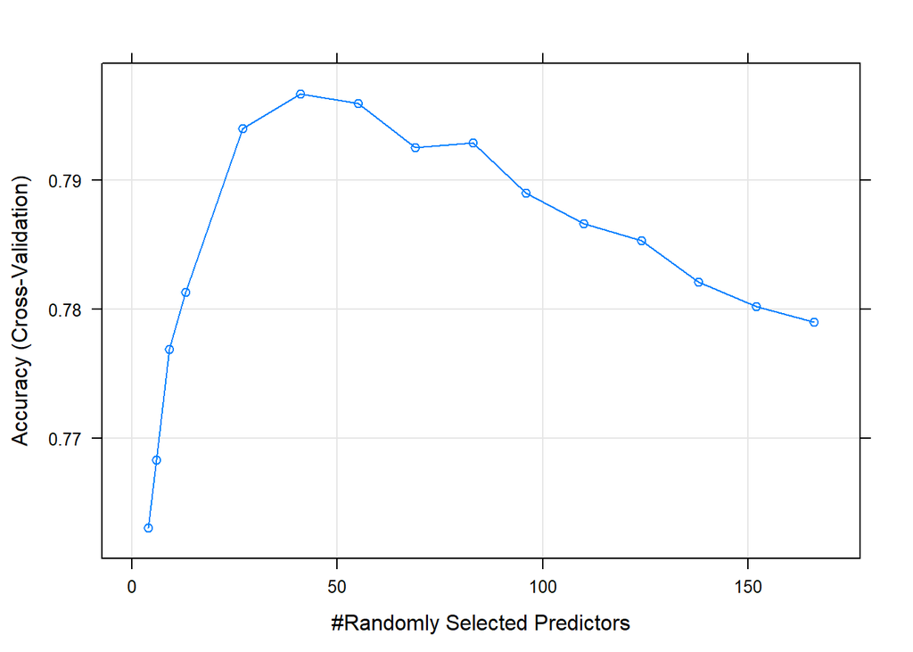

```r
plot(rfFit)
```

```r
load("week-7/problem-set-3/crfFit.RData")

crfFit
```

```
## Conditional Inference Random Forest
##
## 12495 samples
##   191 predictor
##     6 classes: 'Blues', 'Classical', 'Jazz', 'Metal', 'Pop', 'Rock'
##
## Pre-processing: centered (191), scaled (191)
## Resampling: Cross-Validated (10 fold)
## Summary of sample sizes: 173, 174, 167, 177, 167, 174, ...
## Resampling results across tuning parameters:
##
##   mtry  Accuracy   Kappa
##     4   0.7013286  0.6216098
##     6   0.7076341  0.6302044
##     9   0.7107025  0.6344715
##    13   0.7138671  0.6388740
##    27   0.7179079  0.6447118
##    41   0.7165691  0.6436109
##    55   0.7120646  0.6384940
##    69   0.7132908  0.6405587
##    83   0.7090308  0.6355135
##    96   0.7077152  0.6340465
##   110   0.7077236  0.6342662
##   124   0.7078779  0.6347843
##   138   0.7078293  0.6348531
##   152   0.7083002  0.6356182
##   166   0.7061245  0.6329240
##
## Accuracy was used to select the optimal model using the largest value.
## The final value used for the model was mtry = 27.
```

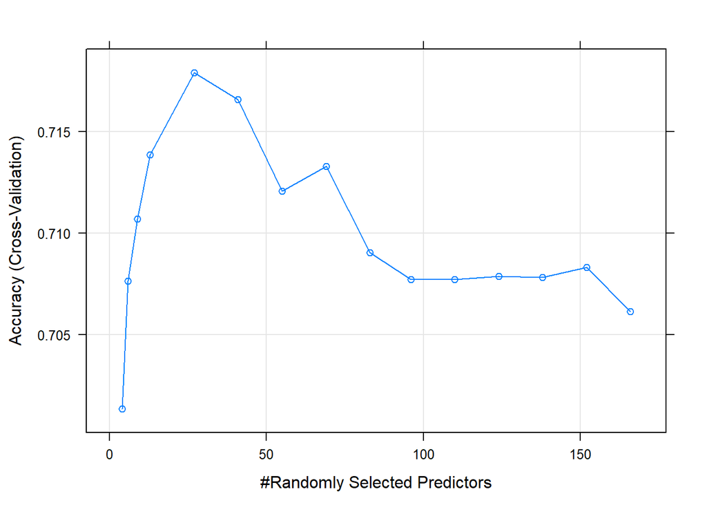

```r
plot(crfFit)
```

We see that the random forest built with regular classification trees seemed to perform better in terms of accuracy than the one built using conditional inference trees. The conditional inference trees took substantially longer to run, and the storage for the `caret` train results was around 2 GB compared to the 45 MB of the regular random forest. The conditional inference trees use a different algorithm to choose which parameters are kept which, among other things, helps when predictor variables are correlated with each other. The conditional inference trees found maximum accuracy at 27 parameters selected, whereas the regular trees was at 41.

### 2

**Data Splitting**: What data splitting method(s) would you use for these data? Explain.

```r
table(genres$GENRE)
```

```
##
##     Blues Classical      Jazz     Metal       Pop      Rock
##      1596      3444      3003       924      1575      1953
```

```r
prop.table(table(genres$GENRE))
```

```
##
##      Blues  Classical       Jazz      Metal        Pop       Rock
## 0.12773109 0.27563025 0.24033613 0.07394958 0.12605042 0.15630252
```

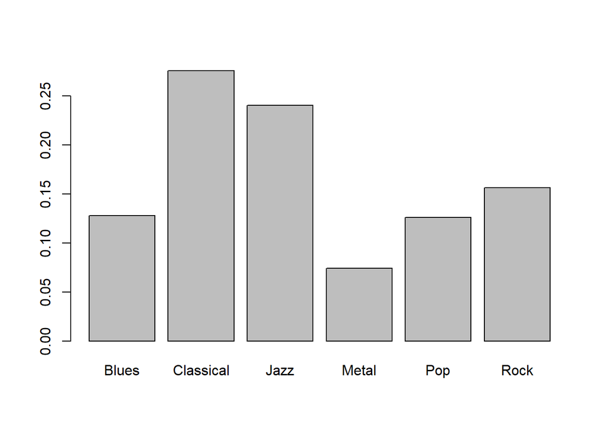

```r
barplot(prop.table(table(genres$GENRE)))
```

```r
for (i in 1:10) {
  print(prop.table(table(genres[tenFoldCV[[i]],]$GENRE)))
}
```

```
##
##      Blues  Classical       Jazz      Metal        Pop       Rock
## 0.14450867 0.24277457 0.25433526 0.06936416 0.12716763 0.16184971
##
##      Blues  Classical       Jazz      Metal        Pop       Rock
## 0.14942529 0.23563218 0.26436782 0.06321839 0.13218391 0.15517241
##
##      Blues  Classical       Jazz      Metal        Pop       Rock
## 0.12574850 0.23952096 0.28143713 0.07185629 0.12574850 0.15568862
##
##      Blues  Classical       Jazz      Metal        Pop       Rock
## 0.14689266 0.24293785 0.27118644 0.07344633 0.12429379 0.14124294
##
##      Blues  Classical       Jazz      Metal        Pop       Rock
## 0.14970060 0.22754491 0.25748503 0.06586826 0.13772455 0.16167665
##
##      Blues  Classical       Jazz      Metal        Pop       Rock
## 0.14367816 0.24712644 0.27011494 0.06321839 0.11494253 0.16091954
##
##      Blues  Classical       Jazz      Metal        Pop       Rock
## 0.14942529 0.24137931 0.27011494 0.06321839 0.12068966 0.15517241
##
##      Blues  Classical       Jazz      Metal        Pop       Rock
## 0.15168539 0.23595506 0.26404494 0.06741573 0.12359551 0.15730337
##
##      Blues  Classical       Jazz      Metal        Pop       Rock
## 0.15384615 0.24260355 0.25443787 0.07100592 0.12426036 0.15384615
##
##      Blues  Classical       Jazz      Metal        Pop       Rock
## 0.14285714 0.24000000 0.26857143 0.06857143 0.12000000 0.16000000
```

### 3

**Variable Importance**: Create a variable importance plot from you best model. What features are most important?

```r
varImp(rfFit)
```

```
## rf variable importance
##
##   only 20 most important variables shown (out of 191)
##
##                      Overall
## PAR_SFMV24            100.00
## PAR_SFM24              82.13
## PAR_SFM22              53.07
## PAR_ASE32              40.82
## PAR_MFCCV1             24.62
## PAR_MFCC1              21.37
## PAR_SFM_MV             20.28
## PAR_ASE_MV             19.20
## PAR_ASS                16.45
## PAR_ASE2               16.28
## PAR_ASE3               15.98
## PAR_ASEV1              15.97
## PAR_SFM23              15.68
## PAR_SFMV22             13.78
## PAR_ASEV3              12.64
## PAR_PEAK_RMS_TOT       12.59
## PAR_SFMV15             12.18
## PAR_ASE4               12.03
## PAR_PEAK_RMS10FR_VAR   11.89
## PAR_ASEV2              11.61
```

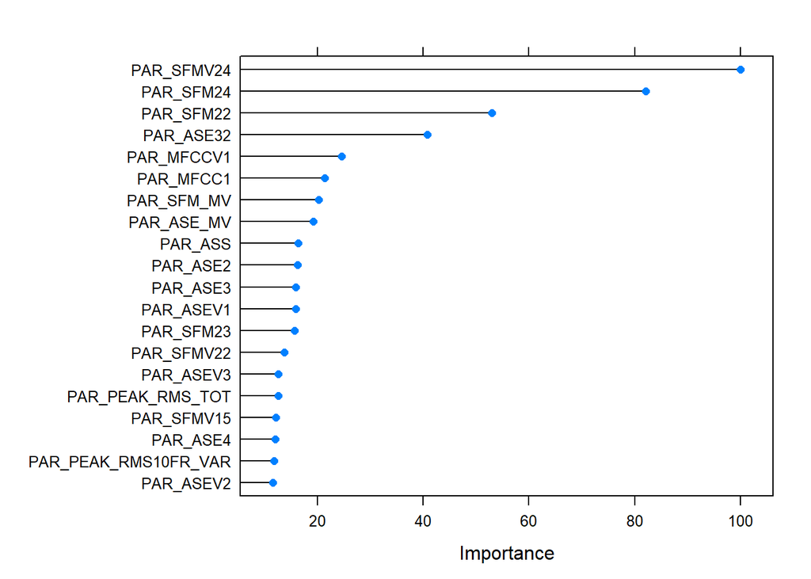

```r
plot(varImp(rfFit), top = 20)
```

We see here the top 20 most important factors for the regular random forest model. It is possible that because of the correlation of the predictors, and the fact that the observations are not independent of each other, that the conditional random forest is actually the better fit and that the regular random forest overestimates the accuracy. We see below that several variables are basically perfectly correlated with each other.

```r
data = as.data.frame(as.table(cor(genres[,1:191])))
combinations = combn(colnames(genres[,1:191]), 2, FUN = function(x) {paste(x, collapse="_")})
data = data[data$Var1!=data$Var2, ]
data = data[paste(data$Var1, data$Var2, sep="_") %in% combinations, ]
head(data[order(-abs(data$Freq)),], 30)
```

```
##               Var1                   Var2      Freq
## 28397    PAR_MFCC2             PAR_MFCCV2 1.0000000
## 28589    PAR_MFCC3             PAR_MFCCV3 1.0000000
## 28781    PAR_MFCC4             PAR_MFCCV4 1.0000000
## 28973    PAR_MFCC5             PAR_MFCCV5 1.0000000
## 29165    PAR_MFCC6             PAR_MFCCV6 1.0000000
## 29357    PAR_MFCC7             PAR_MFCCV7 1.0000000
## 29549    PAR_MFCC8             PAR_MFCCV8 1.0000000
## 29741    PAR_MFCC9             PAR_MFCCV9 1.0000000
## 29933   PAR_MFCC10            PAR_MFCCV10 1.0000000
## 30125   PAR_MFCC11            PAR_MFCCV11 1.0000000
## 30317   PAR_MFCC12            PAR_MFCCV12 1.0000000
## 30893   PAR_MFCC15            PAR_MFCCV15 1.0000000
## 31085   PAR_MFCC16            PAR_MFCCV16 1.0000000
## 31277   PAR_MFCC17            PAR_MFCCV17 1.0000000
```

[output cut: 16 more lines]

### Simulated data

Friedman introduced several benchmark data sets create by simulation. One of these simulations used the following nonlinear equation to create data:

$$y = 10\sin(πx_1x_2)+20(x_3 −0.5)^2 +10x_4 +5x_5 +N(0,σ^2)$$
where the x values are random variables uniformly distributed between [0, 1] (there are also 5 other non-informative variables also created in the simulation). The package mlbench contains a function called `mlbench.friedman1` that simulates these data.

```r
library(mlbench)
set.seed(200)
simulated <- mlbench.friedman1(200, sd = 1)
simulated <- cbind(simulated$x, simulated$y)
simulated <- as.data.frame(simulated)
colnames(simulated)[ncol(simulated)] <- "y"

simulated.copy <- simulated
```

### 4

**Random Forest and Variable Importance**: Fit a random forest model to all of the predictors, then estimate the variable importance scores. Did the random forest model significantly use the uninformative predictors (V6 – V10)?

```r
rfFit.2 <- train(y ~ .,
                  data = simulated,
                  method = "rf",
                  importance = TRUE)

rfFit.2
```

```
## Random Forest
##
## 200 samples
##  10 predictor
##
## No pre-processing
## Resampling: Bootstrapped (25 reps)
## Summary of sample sizes: 200, 200, 200, 200, 200, 200, ...
## Resampling results across tuning parameters:
##
##   mtry  RMSE      Rsquared   MAE
##    2    2.945743  0.7937671  2.427744
##    6    2.558806  0.7739091  2.088545
##   10    2.554602  0.7545765  2.072559
##
## RMSE was used to select the optimal model using the smallest value.
## The final value used for the model was mtry = 10.
```

```r
varImp(rfFit.2)
```

```
## rf variable importance
##
##     Overall
## V1  100.000
## V4   93.115
## V2   86.530
## V5   47.135
## V3   23.973
## V6   11.466
## V10  10.248
## V7    6.974
## V8    5.307
## V9    0.000
```

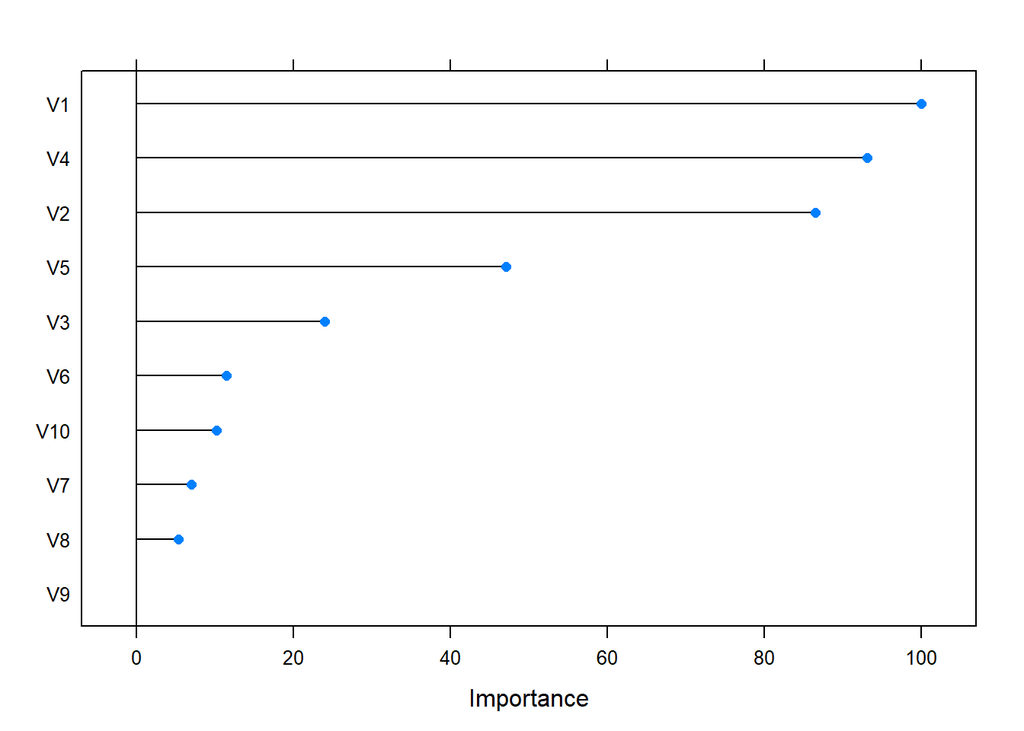

```r
plot(varImp(rfFit.2))
```

As we would expect, we see that V6-V10 are the five least important predictors.

### 5

**Correlated Predictor**:Now add an additional predictor that is highly correlated with one of the informative predictors. For example:

```r
simulated$duplicate1 <- simulated$V1 + rnorm(200) * .1
cor(simulated$duplicate1, simulated$V1)
```

```
## [1] 0.9425982
```

Fit another random forest model to these data. Did the importance score for V1 change? What happens when you add another predictor that is also highly correlated with V1?

```r
rfFit.2 <- train(y ~ .,
                  data = simulated,
                  method = "rf",
                  importance = TRUE)

rfFit.2
```

```
## Random Forest
##
## 200 samples
##  11 predictor
##
## No pre-processing
## Resampling: Bootstrapped (25 reps)
## Summary of sample sizes: 200, 200, 200, 200, 200, 200, ...
## Resampling results across tuning parameters:
##
##   mtry  RMSE      Rsquared   MAE
##    2    2.964840  0.7657863  2.443858
##    6    2.675692  0.7572106  2.204106
##   11    2.679068  0.7369381  2.194160
##
## RMSE was used to select the optimal model using the smallest value.
## The final value used for the model was mtry = 6.
```

```r
varImp(rfFit.2)
```

```
## rf variable importance
##
##            Overall
## V4         100.000
## V2          94.647
## V1          64.985
## V5          47.061
## duplicate1  38.697
## V3          15.779
## V6          12.867
## V10          4.948
## V7           4.140
## V9           1.158
## V8           0.000
```

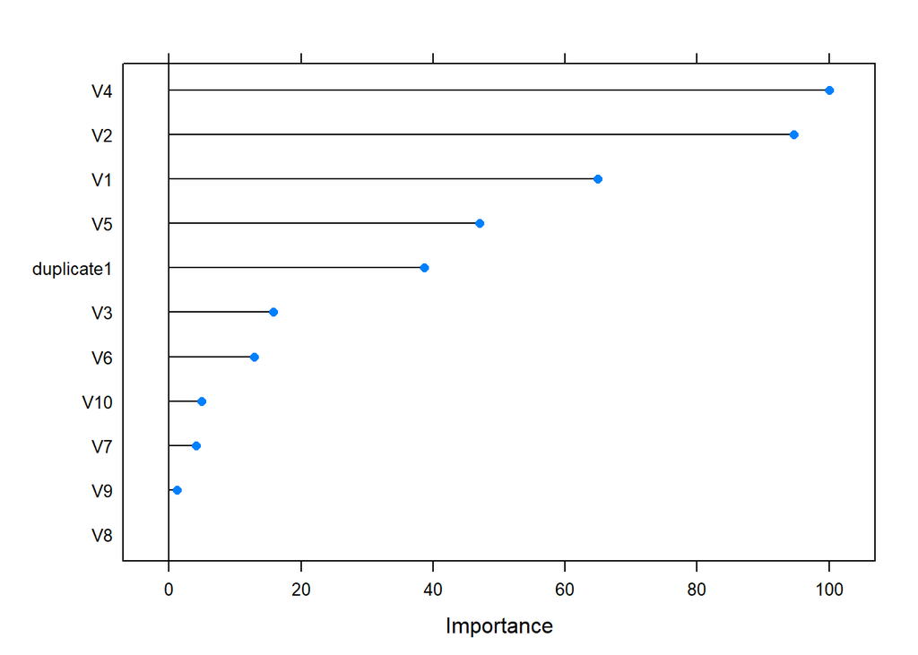

```r
plot(varImp(rfFit.2))
```

When we add in a predictor that correlates with one of the function inputs (V1 in this case), that importance is brought down and the correlated predictor shows up as being fairly important. Basically, they are splitting the importance because when V1 is not included in the model, most of that can be made up by including the duplicated variable instead and so the relative importance of including the actual input variable is lessened.

```r
simulated$duplicate2 <- simulated$V1 + rnorm(200) * .4
cor(simulated$duplicate2, simulated$V1)
```

```
## [1] 0.558283
```

```r
rfFit.2 <- train(y ~ .,
                  data = simulated,
                  method = "rf",
                  importance = TRUE)

rfFit.2
```

```
## Random Forest
##
## 200 samples
##  12 predictor
##
## No pre-processing
## Resampling: Bootstrapped (25 reps)
## Summary of sample sizes: 200, 200, 200, 200, 200, 200, ...
## Resampling results across tuning parameters:
##
##   mtry  RMSE      Rsquared   MAE
##    2    3.013604  0.7520446  2.454491
##    7    2.671135  0.7515170  2.180658
##   12    2.702354  0.7282047  2.200910
##
## RMSE was used to select the optimal model using the smallest value.
## The final value used for the model was mtry = 7.
```

```r
varImp(rfFit.2)
```

```
## rf variable importance
##
##            Overall
## V4         100.000
## V2          89.074
## V1          62.097
## V5          41.829
## duplicate1  38.135
## V3          20.447
## duplicate2  11.853
## V6          11.600
## V10         10.428
## V7           9.456
## V9           6.868
## V8           0.000
```

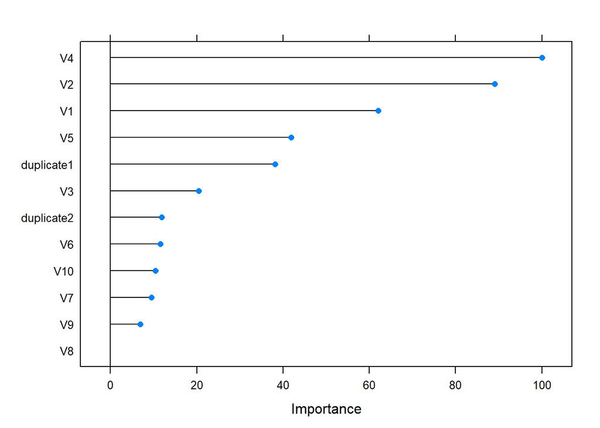

```r
plot(varImp(rfFit.2))
```

When we add in yet another variable correlated with V1, the relative importance of including that variable continues to lessen as there are alternatives that explain the variation fairly well to choose from. This time that effect manifests itself in splitting importance between the two duplicates, which are by definition also correlated to each other.

### 6

**Gradient Boosted Machine**: Repeat the process in 5 and 6 with different tree models, such as boosted trees. Does the same pattern occur?

```r
set.seed(33)
gbmFit <- train(y ~ .,
                  data = simulated.copy,
                  method = "gbm",
                  verbose = FALSE)

varImp(gbmFit)
```

```
## gbm variable importance
##
##      Overall
## V4  100.0000
## V1   88.7191
## V2   67.5477
## V5   43.0598
## V3   27.6035
## V7    2.6158
## V9    1.2016
## V6    1.0616
## V8    0.1451
## V10   0.0000
```

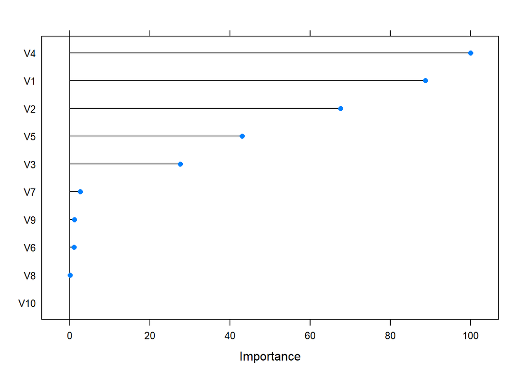

```r
plot(varImp(gbmFit))
```

We see with the GBM that not only are V6-V10 the 5 predictors with the lowest importance, but the importances are actually much closer to 0. Gradient boosted machines are built in series rather than parallel as random forests are. This means that the trees can learn from the previous trees about what was predicted well and what was not, so predictors that are more highly correlated with the output are given greater importance because the marginal improvements made by using the actual inputs are weighted appropriately.

```r
simulated.copy$duplicate1 <- simulated$V1 + rnorm(200) * .1
cor(simulated.copy$duplicate1, simulated$V1)
```

```
## [1] 0.9398278
```

```r
gbmFit <- train(y ~ .,
                  data = simulated.copy,
                  method = "gbm",
                  verbose = FALSE)

varImp(gbmFit)
```

```
## gbm variable importance
##
##             Overall
## V4         100.0000
## V1          75.2939
## V2          68.0874
## V5          39.3799
## V3          25.9848
## duplicate1  15.1506
## V7           1.1132
## V8           1.0841
## V6           0.7966
## V9           0.4021
## V10          0.0000
```

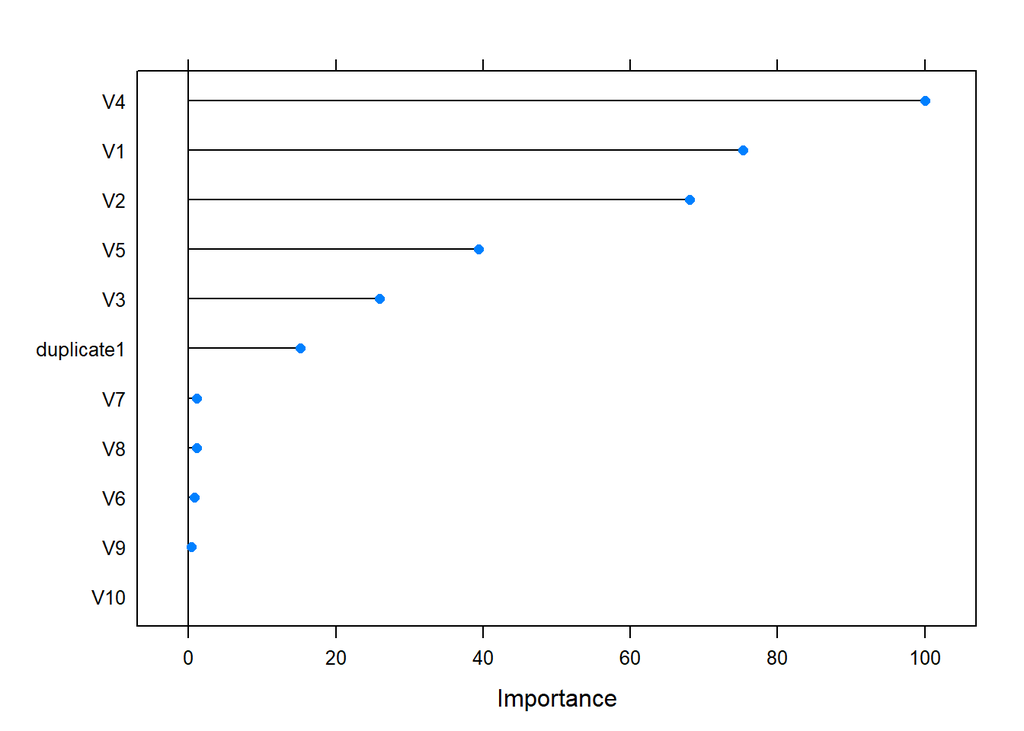

```r
plot(varImp(gbmFit))
```

```r
simulated.copy$duplicate2 <- simulated$V1 + rnorm(200) * .4
cor(simulated.copy$duplicate2, simulated$V1)
```

```
## [1] 0.5719401
```

```r
gbmFit <- train(y ~ .,
                  data = simulated.copy,
                  method = "gbm",
                  verbose = FALSE)

varImp(gbmFit)
```

```
## gbm variable importance
##
##             Overall
## V4         100.0000
## V2          80.7655
## V1          71.8704
## V5          36.3289
## V3          25.4771
## duplicate1  15.2234
## duplicate2   5.8229
## V6           1.8393
## V7           1.4445
## V8           1.0804
## V10          0.9977
## V9           0.0000
```

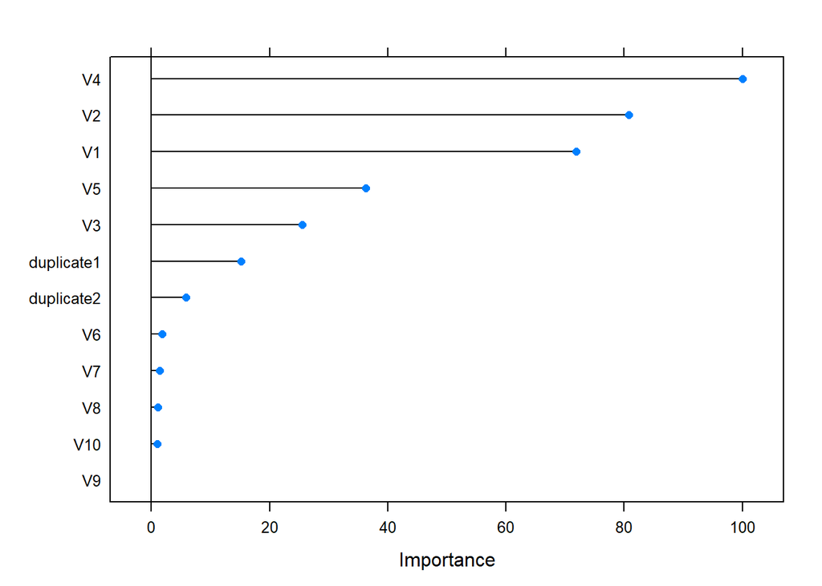

```r
plot(varImp(gbmFit))
```

The importance of V1 does decrease a bit, but not nearly to the extent that we saw with the random forests. The correlated variables are appropriately more important than the uninformative predictors, but still very low considered to the rest of the actual inputs.

### Pulling Punches Part 2

The two `.Rdata` files under week 7 come as an abbreviated version of punch profiles from a boxing system to measure acceleration of boxers during live fights. The `gridded` list from the second file below has each individual punch profile which has a list item being a 3 column data frame of time (in ms around the middle of the punch event), acceleration in x (forward-back in g’s), and acceleration in y (side-to-side in g’s). Also attached are some other fields which are of less importance and contribute to this being a somewhat messy data set.

```r
set.seed(532)

load(file = 'week-7/problem-set-3/boxer_features_and_force.Rdata')
load(file = 'week-7/problem-set-3/force_punch_profiles.Rdata')
```

There are 1000 punch profiles each with an associated force (in Newtons) and boxer who threw the punch. Use the `ff` data frame as ground truth for punch force (variable =`force`) in addition to the rest of the boxer information. Other boxer information included variables around their size to be a proxy for ‘effective mass’.

```r
N = length(gridded)
profLong <- data.frame(matrix(ncol = 4, nrow = 1001*N))

for (i in 1:N) {

 if (i==1) {
   profLong <- cbind(rep(i, 1001), gridded[[i]]$profile)
 }
 else {
   profLong <- rbind(profLong,
                     cbind(rep(i, 1001),
                           gridded[[i]]$profile))
 }

}

profLong <- as.data.table(profLong)

save(profLong, file="profLong.RData")
```

```r
load(file="week-7/problem-set-3/profLong.RData")

N = max(profLong$V1)
features <- data.frame(matrix(ncol = 45, nrow = N))

for (i in 1:N) {

 temp.row <- c(i, max(profLong[V1==i,]$V3))
 temp.row <- c(temp.row, max(profLong[V1==i,]$V4))
 temp.row <- c(temp.row, min(profLong[V1==i,]$V3))
 temp.row <- c(temp.row, min(profLong[V1==i,]$V4))
 temp.gam <- gam(V3 ~ s(V2, k = 20, bs = "cs"),
                 data = profLong[V1==i,])
 temp.row <- c(temp.row, temp.gam$coefficients)
 temp.gam <- gam(V4 ~ s(V2, k = 20, bs = "cs"),
                 data = profLong[V1==i,])
 temp.row <- c(temp.row, temp.gam$coefficients)

 if (i==1) features <- temp.row
 else features <- rbind(features, temp.row)

}

save(features, file="week-7/problem-set-3/features.RData")
```

### 7

**Estimations**: Use features (and/or new features) created from your problem set 2 to estimate punch force using a MARS model. Use RMSE as your error estimate

```r
load(file="week-7/problem-set-3/features.RData")

fulldata <- cbind(features, ff$force)
fulldata <- fulldata[, -c(1)]
colnames(fulldata) <- paste0("V", 1:45)

marsFit <- train(V45 ~ .,
                  data = fulldata,
                  method = "bagEarth")

marsFit
```

```
## Bagged MARS
##
## 1000 samples
##   44 predictor
##
## No pre-processing
## Resampling: Bootstrapped (25 reps)
## Summary of sample sizes: 1000, 1000, 1000, 1000, 1000, 1000, ...
## Resampling results across tuning parameters:
##
##   nprune  RMSE      Rsquared   MAE
##    2      995.0542  0.2705744  755.0249
##   10      773.3631  0.5446960  577.4485
##   18      750.9669  0.5688855  553.6208
##
## Tuning parameter 'degree' was held constant at a value of 1
## RMSE was used to select the optimal model using the smallest value.
## The final values used for the model were nprune = 18 and degree = 1.
```

### 8

**Estimations improved** Now try a few different (gbm, randomForest) models through the `caret` package and different data splitting techniques to compare. Comparing RMSE which model performs the best?

```r
rfFit.3 <- train(V45 ~ .,
                  data = fulldata,
                  method = "rf")

rfFit.3
```

```
## Random Forest
##
## 1000 samples
##   44 predictor
##
## No pre-processing
## Resampling: Bootstrapped (25 reps)
## Summary of sample sizes: 1000, 1000, 1000, 1000, 1000, 1000, ...
## Resampling results across tuning parameters:
##
##   mtry  RMSE      Rsquared   MAE
##    2    678.7529  0.7265671  502.1603
##   23    637.9937  0.7019926  464.6627
##   44    650.9776  0.6796596  469.5738
##
## RMSE was used to select the optimal model using the smallest value.
## The final value used for the model was mtry = 23.
```

```r
gbmFit.3 <- train(V45 ~ .,
                    data = fulldata,
                    method = "gbm",
                    verbose = FALSE)

gbmFit.3
```

```
## Stochastic Gradient Boosting
##
## 1000 samples
##   44 predictor
##
## No pre-processing
## Resampling: Bootstrapped (25 reps)
## Summary of sample sizes: 1000, 1000, 1000, 1000, 1000, 1000, ...
## Resampling results across tuning parameters:
##
##   interaction.depth  n.trees  RMSE      Rsquared   MAE
##   1                   50      831.6382  0.4869885  630.0482
##   1                  100      781.3946  0.5351372  586.2589
##   1                  150      756.1450  0.5625630  564.8635
##   2                   50      753.3854  0.5759203  568.1539
##   2                  100      701.4064  0.6254609  524.2921
##   2                  150      678.3995  0.6476058  504.8844
##   3                   50      712.7144  0.6160013  534.2792
##   3                  100      670.2365  0.6553846  496.4258
##   3                  150      652.1055  0.6728086  481.9397
##
## Tuning parameter 'shrinkage' was held constant at a value of 0.1
##
## Tuning parameter 'n.minobsinnode' was held constant at a value of 10
## RMSE was used to select the optimal model using the smallest value.
## The final values used for the model were n.trees = 150,
##  interaction.depth = 3, shrinkage = 0.1 and n.minobsinnode = 10.
```

```r
svmFit <- train(V45 ~ .,
                data = fulldata,
                method = "svmRadial")

svmFit
```

```
## Support Vector Machines with Radial Basis Function Kernel
##
## 1000 samples
##   44 predictor
##
## No pre-processing
## Resampling: Bootstrapped (25 reps)
## Summary of sample sizes: 1000, 1000, 1000, 1000, 1000, 1000, ...
## Resampling results across tuning parameters:
##
##   C     RMSE      Rsquared   MAE
##   0.25  743.9798  0.6454814  507.5150
##   0.50  651.7169  0.7157195  459.3927
##   1.00  579.0709  0.7626195  423.9154
##
## Tuning parameter 'sigma' was held constant at a value of 0.01689396
## RMSE was used to select the optimal model using the smallest value.
## The final values used for the model were sigma = 0.01689396 and C = 1.
```

We see that the SVM produces the lowest RMSE and the MARS model produces the highest (SVM > RF > GBM > MARS). Furthermore, we can try different splitting techniques on the SVM.

```r
svmFitB632 <- train(V45 ~ .,
                    data = fulldata,
                    method = "svmRadial",
                    trControl = trainControl(method = "boot632",
                                              number = 50))

svmFitB632
```

```
## Support Vector Machines with Radial Basis Function Kernel
##
## 1000 samples
##   44 predictor
##
## No pre-processing
## Resampling: Bootstrapped (50 reps)
## Summary of sample sizes: 1000, 1000, 1000, 1000, 1000, 1000, ...
## Resampling results across tuning parameters:
##
##   C     RMSE      Rsquared   MAE
##   0.25  704.1301  0.6727395  477.9962
##   0.50  600.5537  0.7488816  419.2242
##   1.00  519.8494  0.7977589  372.3156
##
## Tuning parameter 'sigma' was held constant at a value of 0.01595604
## RMSE was used to select the optimal model using the smallest value.
## The final values used for the model were sigma = 0.01595604 and C = 1.
```

```r
svmFitCV <- train(V45 ~ .,
                  data = fulldata,
                  method = "svmRadial",
                  trControl = trainControl(method = "cv",
                                            number = 10))

svmFitCV
```

```
## Support Vector Machines with Radial Basis Function Kernel
##
## 1000 samples
##   44 predictor
##
## No pre-processing
## Resampling: Cross-Validated (10 fold)
## Summary of sample sizes: 900, 901, 899, 900, 900, 900, ...
## Resampling results across tuning parameters:
##
##   C     RMSE      Rsquared   MAE
##   0.25  731.9647  0.6531333  502.9041
##   0.50  634.7510  0.7248305  451.7680
##   1.00  550.9177  0.7769907  404.9870
##
## Tuning parameter 'sigma' was held constant at a value of 0.01540273
## RMSE was used to select the optimal model using the smallest value.
## The final values used for the model were sigma = 0.01540273 and C = 1.
```

```r
svmFitLGO <- train(V45 ~ .,
                    data = fulldata,
                    method = "svmRadial",
                    trControl = trainControl(method = "LGOCV",
                                              number = 50,
                                              p = .8))

svmFitLGO
```

```
## Support Vector Machines with Radial Basis Function Kernel
##
## 1000 samples
##   44 predictor
##
## No pre-processing
## Resampling: Repeated Train/Test Splits Estimated (50 reps, 80%)
## Summary of sample sizes: 801, 801, 801, 801, 801, 801, ...
## Resampling results across tuning parameters:
##
##   C     RMSE      Rsquared   MAE
##   0.25  746.8089  0.6347839  505.8800
##   0.50  650.3700  0.7131583  454.2446
##   1.00  566.0544  0.7692240  411.3716
##
## Tuning parameter 'sigma' was held constant at a value of 0.01704011
## RMSE was used to select the optimal model using the smallest value.
## The final values used for the model were sigma = 0.01704011 and C = 1.
```

The 632 bootstap method for splitting the data even further improves the SVM RMSE (BS632 > CV10 > LGO.8).